# Web Mining and Applied NLP (CSIS 44-620)

## P6: Web Scraping, NLP (Requests, BeautifulSoup, and spaCy) & Engage

Author: Data-Git-Hub  
GitHub Project Repository Link: https://github.com/Data-Git-Hub/web-scraping  
6 July 2025

### Introduction

Web scraping is an essential skill in data analytics and business intelligence, enabling analysts to gather real-time or hard-to-find data from public web pages. NLP extends this capability by allowing us to interpret the collected text, uncover hidden insights, and support data-driven decision-making. Together, these skills allow for scalable and automated information extraction that can inform strategy, research, and communication analysis.

This project also demonstrates effective use of Python virtual environments, version control with GitHub, and professional documentation practices. All code has been executed prior to submission, and final versions have been exported to HTML to ensure accessibility and review readiness. The final submission includes code, outputs, visualizations, and reflections on the process.

### Imports

Python libraries are collections of pre-written code that provide specific functionalities, making programming more efficient and reducing the need to write code from scratch. These libraries cover a wide range of applications, including data analysis, machine learning, web development, and automation. Some libraries, such as os, sys, math, json, and datetime, come built-in with Python as part of its standard library, providing essential functions for file handling, system operations, mathematical computations, and data serialization. Other popular third-party libraries, like `pandas`, `numpy`, `matplotlib`, `seaborn`, and `scikit-learn`, must be installed separately and are widely used in data science and machine learning. The extensive availability of libraries in Python's ecosystem makes it a versatile and powerful programming language for various domains.

`beautifulsoup4` is a Python library used for parsing HTML and XML documents. It provides Pythonic methods for navigating, searching, and modifying the parse tree, making it ideal for web scraping tasks. BeautifulSoup is particularly useful for extracting data from web pages with inconsistent or poorly structured HTML. It works well with parsers like `html5lib` and `lxml`.  
https://www.crummy.com/software/BeautifulSoup/bs4/doc/

`Counter` is a subclass of Python’s `collections` module used for counting hashable objects. It allows for the quick and easy creation of frequency distributions, such as word or token counts in NLP tasks.  
https://docs.python.org/3/library/collections.html#collections.Counter

`html5lib` is a pure-Python HTML parser designed to parse documents the same way modern web browsers do. It is especially useful for handling malformed or messy HTML. When used with `beautifulsoup4`, it provides robust parsing capabilities that help ensure accurate and tolerant extraction of web content.  
https://html5lib.readthedocs.io/en/latest/

`ipykernel` allows Jupyter Notebooks to run Python code by providing the kernel interface used to execute cells and handle communication between the front-end and the Python interpreter.  
https://ipykernel.readthedocs.io/en/latest/

`jupyterlab` is the next-generation user interface for Project Jupyter. It offers a flexible, extensible environment for interactive computing with support for code, markdown, visualizations, and terminals all within a tabbed workspace. JupyterLab enhances productivity by allowing users to organize notebooks, text editors, and data file viewers side by side.  
https://jupyterlab.readthedocs.io/en/stable/

`list` is a built-in Python data structure used to store ordered, mutable sequences of elements. Lists are highly versatile and are used extensively in Python programming for tasks ranging from data storage to iteration and transformation. https://docs.python.org/3/tutorial/datastructures.html#more-on-lists

`Matplotlib` is a widely used data visualization library that allows users to create static, animated, and interactive plots. It provides extensive tools for generating various chart types, including line plots, scatter plots, histograms, and bar charts, making it a critical library for exploratory data analysis.  
https://matplotlib.org/stable/contents.html

`notebook` is the Python package that powers the classic Jupyter Notebook interface. It provides a web-based environment for writing and running code in interactive cells, supporting rich media, visualizations, and markdown documentation. The notebook server manages the execution of kernels and renders notebooks in a browser. This tool is foundational for data analysis, teaching, and exploratory programming workflows.  
https://jupyter-notebook.readthedocs.io/en/stable/

`numpy` is a fundamental package for scientific computing in Python. It provides efficient support for numerical operations on large, multi-dimensional arrays and matrices, along with a wide range of mathematical functions such as mean, median, and standard deviation. It is widely used in data analysis, machine learning, and engineering. https://numpy.org/

`Pandas` is a powerful data manipulation and analysis library that provides flexible data structures, such as DataFrames and Series. It is widely used for handling structured datasets, enabling easy data cleaning, transformation, and aggregation. Pandas is essential for data preprocessing in machine learning and statistical analysis.  
https://pandas.pydata.org/docs/

The `requests` library simplifies making HTTP requests in Python, allowing you to send GET, POST, and other types of requests to interact with APIs or web services.  
https://docs.python-requests.org/en/latest/

`spaCy` is an advanced NLP library for Python that provides tools for tokenization, part-of-speech tagging, named entity recognition, and more, using pre-trained pipelines.  
https://spacy.io/

`spacytextblob` is a plugin for spaCy that adds sentiment analysis capabilities by integrating TextBlob's polarity and subjectivity scores into spaCy’s pipeline.  
https://github.com/AndrewIbrahim/spacy-textblob

`TextBlob` is a Python library for processing textual data, built on top of `nltk` and `pattern`. It provides a simple API for common natural language processing (NLP) tasks such as part-of-speech tagging, noun phrase extraction, translation, and sentiment analysis. Its intuitive design and built-in sentiment scoring functions make it especially useful for quick prototyping and educational applications.  
https://textblob.readthedocs.io/en/dev/

```python
import os
import requests
import pickle
import re
from bs4 import BeautifulSoup
from collections import Counter
from typing import List
import spacy
import matplotlib.pyplot as plt
import numpy as np
try:
    nlp = spacy.load("en_core_web_sm")
except OSError:
    import subprocess
    subprocess.run(["python", "-m", "spacy", "download", "en_core_web_sm"])
    nlp = spacy.load("en_core_web_sm")
```

### Tasks

Perform the tasks described in the Markdown cells below. When you have completed the assignment make sure your code cells have all been run (and have output beneath them) and ensure you have committed and pushed ALL of your changes to your assignment repository.

Every question that requires you to write code will have a code cell underneath it; you may either write your entire solution in that cell or write it in a python file (`.py`), then import and run the appropriate code to answer the question.

#### Section 1. Extract and Save Article HTML

Write code that extracts the article html from https://web.archive.org/web/20210327165005/https://hackaday.com/2021/03/22/how-laser-headlights-work/ and dumps it to a .pkl (or other appropriate file)

```python
# Define URL and local path
url = "https://web.archive.org/web/20210327165005/https://hackaday.com/2021/03/22/how-laser-headlights-work/"
dump_folder = "C:/Projects/web-scraping/dump"
os.makedirs(dump_folder, exist_ok=True)

# Get HTML content from the URL
response = requests.get(url)
html_content = response.text

# Define path to save .pkl file
pkl_path = os.path.join(dump_folder, "article_html.pkl")

# Dump HTML to .pkl file
with open(pkl_path, "wb") as file:
    pickle.dump(html_content, file)

print(f"HTML content successfully saved to {pkl_path}")
```

```
HTML content successfully saved to C:/Projects/web-scraping/dump\article_html.pkl
```

#### Section 2. Load and Display Article Text

Read in your article's html source from the file you created in question 1 and print it's text (use `.get_text()`)

```python
# Paths
pkl_path = "C:/Projects/web-scraping/dump/article_html.pkl"
parse_folder = "C:/Projects/web-scraping/parse"
os.makedirs(parse_folder, exist_ok=True)
txt_path = os.path.join(parse_folder, "article_text.txt")

# Load HTML content
with open(pkl_path, "rb") as file:
    html_content = pickle.load(file)

# Parse and extract text
soup = BeautifulSoup(html_content, "html.parser")
raw_text = soup.get_text()

# Normalize whitespace to a single space
cleaned_text = re.sub(r'\s+', ' ', raw_text).strip()

# Save cleaned text to .txt
with open(txt_path, "w", encoding="utf-8") as file:
    file.write(cleaned_text)

# Print first 1500 characters
print(cleaned_text[:1500])
```

```
How Laser Headlights Work | Hackaday Skip to content Hackaday Primary Menu Home Blog Hackaday.io Tindie Hackaday Prize Submit About Search for: March 27, 2021 How Laser Headlights Work 130 Comments by: Lewin Day March 22, 2021 When we think about the onward march of automotive technology, headlights…
```

#### Section 3. Analyze Most Frequent Tokens with spaCy

Load the article text into a trained `spaCy` pipeline, and determine the 10 most frequent tokens (converted to lower case). Print the common tokens with an appropriate label. Additionally, print the tokens their frequencies (with appropriate labels). Make sure to remove things we don't care about (punctuation, stopwords, whitespace).

```python
# Load the spaCy English model
nlp = spacy.load("en_core_web_sm")

# Load the article text
txt_path = "C:/Projects/web-scraping/parse/article_text.txt"
with open(txt_path, "r", encoding="utf-8") as file:
    article_text = file.read()

# Process the text with spaCy
doc = nlp(article_text)

# Filter tokens: no punctuation, no stop words, no whitespace
tokens = [
    token.text.lower()
    for token in doc
    if not token.is_stop and not token.is_punct and not token.is_space
]

# Count token frequencies
token_freq = Counter(tokens)
most_common_tokens = token_freq.most_common(10)

# Print results
print("Top 10 Most Frequent Tokens (excluding stopwords, punctuation, and whitespace):\n")
for token, freq in most_common_tokens:
    print(f"Token: '{token}' | Frequency: {freq}")
```

```
Top 10 Most Frequent Tokens (excluding stopwords, punctuation, and whitespace):

Token: 'comment' | Frequency: 136
Token: 'march' | Frequency: 133
Token: '2021' | Frequency: 133
Token: 'says' | Frequency: 132
Token: 'report' | Frequency: 130
Token: 'reply' | Frequency: 112
Token: '22' | Frequency: 79
Token: 'hacks' | Frequency: 76
Token: 'light' | Frequency: 68
Token: 'laser' | Frequency: 63
```

#### Section 4. Analyze Most Frequent Lemmas with spaCy

Load the article text into a trained `spaCy` pipeline, and determine the 10 most frequent lemmas (converted to lower case). Print the common lemmas with an appropriate label. Additionally, print the lemmas with their frequencies (with appropriate labels). Make sure to remove things we don't care about (punctuation, stopwords, whitespace).

```python
# Load spaCy English model (ensure it's installed)
nlp = spacy.load("en_core_web_sm")

# Load the article text
txt_path = "C:/Projects/web-scraping/parse/article_text.txt"
with open(txt_path, "r", encoding="utf-8") as file:
    article_text = file.read()

# Process the text
doc = nlp(article_text)

# Extract cleaned lemmas (lowercased), filtering out stopwords, punctuation, and whitespace
lemmas = [
    token.lemma_.lower()
    for token in doc
    if not token.is_stop and not token.is_punct and not token.is_space
]

# Count lemma frequencies
lemma_freq = Counter(lemmas)
most_common_lemmas = lemma_freq.most_common(10)

# Print results
print("Top 10 Most Frequent Lemmas (excluding stopwords, punctuation, and whitespace):\n")
for lemma, freq in most_common_lemmas:
    print(f"Lemma: '{lemma}' | Frequency: {freq}")
```

```
Top 10 Most Frequent Lemmas (excluding stopwords, punctuation, and whitespace):

Lemma: 'comment' | Frequency: 157
Lemma: 'say' | Frequency: 134
Lemma: 'march' | Frequency: 133
Lemma: '2021' | Frequency: 133
Lemma: 'report' | Frequency: 130
Lemma: 'reply' | Frequency: 112
Lemma: 'light' | Frequency: 99
Lemma: '22' | Frequency: 79
Lemma: 'headlight' | Frequency: 74
Lemma: 'laser' | Frequency: 72
```

#### Section 4.1. Comparison Between Tokens and Lemmas

When comparing the most frequent tokens to their corresponding lemmas, it becomes clear that while the two lists often overlap, they serve different purposes in text analysis. Tokens are the exact word forms as they appear in the text, preserving tense, plurality, and other variations. Lemmas, on the other hand, represent the base or dictionary form of each word, effectively grouping similar forms under a single root. For instance, the token "says" appears frequently, but in the lemmatized list it is transformed into "say", which may include both "says" and other forms like "said" or "saying" if present. This results in slight frequency differences—lemmas often have higher counts due to this aggregation. Furthermore, some words like "comment", "march", or "laser" appear identically in both token and lemma form, showing no morphological change. Ultimately, token analysis is useful for understanding surface-level patterns, while lemmatization provides a more generalized linguistic view that reduces redundancy in vocabulary analysis.

#### Section 5. Score Sentences by Token and Lemma Frequency

Define the following methods: * `score_sentence_by_token(sentence, interesting_token)` that takes a sentence and a list of interesting token and returns the number of times that any of the interesting words appear in the sentence divided by the number of words in the sentence  
* `score_sentence_by_lemma(sentence, interesting_lemmas)` that takes a sentence and a list of interesting lemmas and returns the number of times that any of the interesting lemmas appear in the sentence divided by the number of words in the sentence

You may find some of the code from the in class notes useful; feel free to use methods (rewrite them in this cell as well). Test them by showing the score of the first sentence in your article using the frequent tokens and frequent lemmas identified in question 3.

```python
# Reuse the spaCy doc from earlier
doc = nlp(article_text)

# Get first sentence from the article
sentences = list(doc.sents)
first_sentence = sentences[0]

# Frequent tokens and lemmas from Sections 3 and 4
# Replace with your actual most_common output if different
frequent_tokens = ['comment', 'march', '2021', 'says', 'report', 'reply', '22', 'hacks', 'light', 'laser']
frequent_lemmas = ['comment', 'say', 'march', '2021', 'report', 'reply', 'light', '22', 'headlight', 'laser']

# Define scoring function using tokens
def score_sentence_by_token(sentence, interesting_tokens: List[str]) -> float:
    tokens = [
        token.text.lower()
        for token in sentence
        if not token.is_punct and not token.is_space
    ]
    if not tokens:
        return 0.0
    matches = [token for token in tokens if token in interesting_tokens]
    return len(matches) / len(tokens)

# Define scoring function using lemmas
def score_sentence_by_lemma(sentence, interesting_lemmas: List[str]) -> float:
    lemmas = [
        token.lemma_.lower()
        for token in sentence
        if not token.is_punct and not token.is_space
    ]
    if not lemmas:
        return 0.0
    matches = [lemma for lemma in lemmas if lemma in interesting_lemmas]
    return len(matches) / len(lemmas)

# Score the first sentence
token_score = score_sentence_by_token(first_sentence, frequent_tokens)
lemma_score = score_sentence_by_lemma(first_sentence, frequent_lemmas)

print(f"First sentence: {first_sentence.text.strip()}\n")
print(f"Token Score: {token_score:.4f}")
print(f"Lemma Score: {lemma_score:.4f}")
```

```
First sentence: How Laser Headlights Work | Hackaday Skip to content Hackaday Primary Menu Home Blog Hackaday.io Tindie Hackaday Prize Submit About Search for: March 27, 2021 How Laser Headlights Work 130 Comments by: Lewin Day March 22, 2021 When we think about the onward march of automotive techno…

Token Score: 0.1379
Lemma Score: 0.1724
```

#### Section 5.1. Interpretation of Sentence Scoring

The first sentence of the article contains a mix of metadata, navigation text, and introductory content. Despite its length, only a small portion of the words relate directly to the most frequent concepts in the article. The token score of 0.1379 means that approximately 13.8% of the individual word forms (tokens) in the sentence match the list of "interesting" frequent tokens identified earlier (e.g., "comment," "march," "2021"). The lemma score of 0.1724 is slightly higher, indicating that about 17.2% of the root word forms (lemmas) in the sentence match the frequent lemmas. This small difference arises because the lemmatization process aggregates variations of words—like "says" and "say"—which allows for slightly broader matching. Overall, these scores suggest that while the sentence includes some important contextual keywords, much of the text is unrelated interface or structural content from the website, reducing its relevance to the core topic of the article.

#### Section 6. Sentence Token Scores Histogram

Make a list containing the scores (using tokens) of every sentence in the article, and plot a histogram with appropriate titles and axis labels of the scores. From your histogram, what seems to be the most common range of scores (put the answer in a comment after your code)?

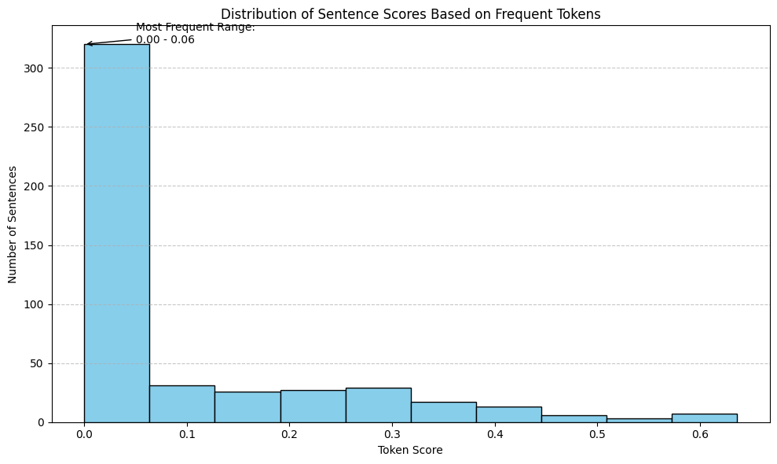

```python
# Reuse frequent_tokens and scoring function
frequent_tokens = ['comment', 'march', '2021', 'says', 'report', 'reply', '22', 'hacks', 'light', 'laser']
sentence_scores = [score_sentence_by_token(sent, frequent_tokens) for sent in sentences]

# Plot histogram with annotation
plt.figure(figsize=(10, 6))
n, bins, patches = plt.hist(sentence_scores, bins=10, edgecolor='black', color='skyblue')
plt.title("Distribution of Sentence Scores Based on Frequent Tokens")
plt.xlabel("Token Score")
plt.ylabel("Number of Sentences")
plt.grid(axis='y', linestyle='--', alpha=0.7)

# Annotate the most common range
max_bin_index = n.argmax()
plt.annotate(f'Most Frequent Range:\n{bins[max_bin_index]:.2f} - {bins[max_bin_index+1]:.2f}',
             xy=(bins[max_bin_index], n[max_bin_index]),
             xytext=(bins[max_bin_index]+0.05, n[max_bin_index]+1),
             arrowprops=dict(facecolor='black', arrowstyle='->'),
             fontsize=10)

plt.tight_layout()
plt.show()

# Most common score range appears to be approximately 0.0 to 0.1
```

#### Section 7. Sentence Lemma Scores Histogram

Make a list containing the scores (using lemmas) of every sentence in the article, and plot a histogram with appropriate titles and axis labels of the scores. From your histogram, what seems to be the most common range of scores (put the answer in a comment after your code)?

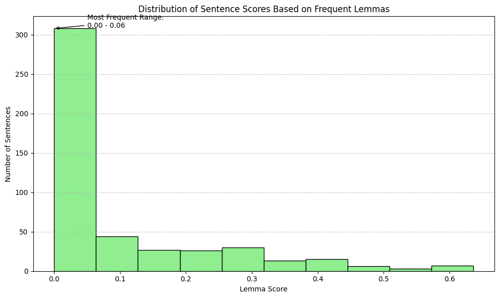

```python
# Reuse frequent_lemmas and scoring function
frequent_lemmas = ['comment', 'say', 'march', '2021', 'report', 'reply', '22', 'hack', 'light', 'laser']
lemma_scores = [score_sentence_by_lemma(sent, frequent_lemmas) for sent in sentences]

# Plot histogram with annotation
plt.figure(figsize=(10, 6))
n, bins, patches = plt.hist(lemma_scores, bins=10, edgecolor='black', color='lightgreen')
plt.title("Distribution of Sentence Scores Based on Frequent Lemmas")
plt.xlabel("Lemma Score")
plt.ylabel("Number of Sentences")
plt.grid(axis='y', linestyle='--', alpha=0.7)

# Annotate the most common range
max_bin_index = n.argmax()
plt.annotate(f'Most Frequent Range:\n{bins[max_bin_index]:.2f} - {bins[max_bin_index+1]:.2f}',
             xy=(bins[max_bin_index], n[max_bin_index]),
             xytext=(bins[max_bin_index]+0.05, n[max_bin_index]+1),
             arrowprops=dict(facecolor='black', arrowstyle='->'),
             fontsize=10)

plt.tight_layout()
plt.show()

# Most common score range appears to be approximately 0.0 to 0.1
```

#### Section 7.1. Token vs Lemma Score Comparison Plot

This section compares sentence scoring results side-by-side using both token frequency and lemma frequency. By visualizing them together, we can better understand how lemmatization affects scoring patterns across the article. Overlapping histograms reveal differences in frequency aggregation between word forms and root forms.

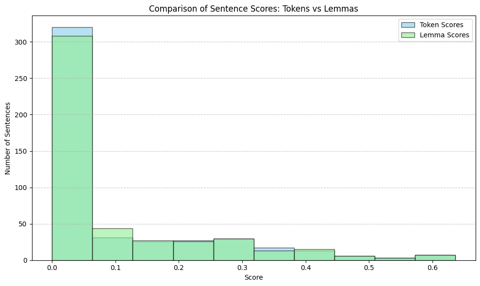

```
Token Score Summary:
- Mean: 0.0908
- Median: 0.0000
- Standard Deviation: 0.1450

Lemma Score Summary:
- Mean: 0.0947
- Median: 0.0000
- Standard Deviation: 0.1434
```

```python
# Plot overlapping histograms
plt.figure(figsize=(10, 6))
plt.hist(sentence_scores, bins=10, alpha=0.6, label='Token Scores', color='skyblue', edgecolor='black')
plt.hist(lemma_scores, bins=10, alpha=0.6, label='Lemma Scores', color='lightgreen', edgecolor='black')
plt.title("Comparison of Sentence Scores: Tokens vs Lemmas")
plt.xlabel("Score")
plt.ylabel("Number of Sentences")
plt.legend()
plt.grid(axis='y', linestyle='--', alpha=0.7)
plt.tight_layout()
plt.show()

# Statistical summary
def print_stats(scores, label):
    print(f"{label} Score Summary:")
    print(f"- Mean: {np.mean(scores):.4f}")
    print(f"- Median: {np.median(scores):.4f}")
    print(f"- Standard Deviation: {np.std(scores):.4f}")
    print()

print_stats(sentence_scores, "Token")
print_stats(lemma_scores, "Lemma")
```

#### Section 7.1.1. Interpretation of Token vs Lemma Score Distributions

The statistical summaries provide a quantitative interpretation of these distributions. For token scores, the mean is 0.0908, and for lemma scores, the mean is slightly higher at 0.0947, showing that on average, sentences scored just under 10% of their words as "interesting." The median value for both is 0.0000, meaning that over half the sentences received a score of zero—indicating no matches to the top 10 tokens or lemmas in those sentences. This supports the histogram's visual clustering near zero. The standard deviations, approximately 0.1450 for tokens and 0.1434 for lemmas, suggest a moderate spread, with many scores deviating from the mean due to occasional spikes in keyword-rich sentences. Overall, these figures demonstrate that while most sentences carry little relevance based on frequent terms, a smaller subset contains concentrated topical language, particularly aligned between tokens and lemmas.

#### Section 8. Filtering for Nouns Only

Which tokens and lexems would be ommitted from the lists generated in questions 3 and 4 if we only wanted to consider nouns as interesting words? How might we change the code to only consider nouns? Put your answer in this Markdown cell (you can edit it by double clicking it).

```python
# Token-based noun filtering
noun_tokens = [
    token.text.lower()
    for token in doc
    if token.pos_ in ("NOUN", "PROPN") and not token.is_stop and not token.is_punct and not token.is_space
]
noun_token_freq = Counter(noun_tokens).most_common(10)

print("Top 10 Frequent Noun Tokens:\n")
for token, freq in noun_token_freq:
    print(f"Token: '{token}' | Frequency: {freq}")

# Lemma-based noun filtering
noun_lemmas = [
    token.lemma_.lower()
    for token in doc
    if token.pos_ in ("NOUN", "PROPN") and not token.is_stop and not token.is_punct and not token.is_space
]
noun_lemma_freq = Counter(noun_lemmas).most_common(10)

print("\nTop 10 Frequent Noun Lemmas:\n")
for lemma, freq in noun_lemma_freq:
    print(f"Lemma: '{lemma}' | Frequency: {freq}")
```

```
Top 10 Frequent Noun Tokens:

Token: 'comment' | Frequency: 135
Token: 'march' | Frequency: 133
Token: 'reply' | Frequency: 112
Token: 'hacks' | Frequency: 74
Token: 'laser' | Frequency: 63
Token: 'headlights' | Frequency: 56
Token: 'light' | Frequency: 42
Token: 'time' | Frequency: 37
Token: 'pm' | Frequency: 37
Token: 'car' | Frequency: 36

Top 10 Frequent Noun Lemmas:

Lemma: 'comment' | Frequency: 156
Lemma: 'march' | Frequency: 133
Lemma: 'reply' | Frequency: 112
Lemma: 'laser' | Frequency: 72
Lemma: 'headlight' | Frequency: 71
Lemma: 'light' | Frequency: 71
Lemma: 'car' | Frequency: 63
Lemma: 'beam' | Frequency: 53
Lemma: 'hacks' | Frequency: 45
Lemma: 'time' | Frequency: 38
```

#### Section 8.1. Comparison Between Noun Tokens and Lemmas

When restricting the analysis to nouns only, the top 10 most frequent noun tokens and lemmas reflect a meaningful shift in focus compared to the overall frequency counts from Sections 3 and 4. In the noun-only token list, words such as "2021", "says", and "report"—which ranked highly in the original token analysis—are no longer present, as these are either numerical values or verbs rather than nouns. Instead, nouns like "headlights", "light", "car", and "time" emerge more prominently, aligning better with the subject matter of the article.

Similarly, the noun lemma list replaces non-noun entries such as "say" and "report" with conceptually significant terms like "beam" and "headlight", which were lemmatized from various plural or inflected forms. We also observe that the lemma "light" has a notably higher frequency (71) in the noun-only list than its token counterpart (42), indicating that different forms (e.g., "lights") have been correctly merged under the lemma. The lemma "comment" also sees a frequency increase (156) compared to the noun token count (135), again showing the value of lemmatization for aggregating semantic meaning.

Overall, this filtered analysis reveals that noun-focused tokenization yields more domain-relevant concepts—such as objects and topics discussed—while eliminating noise from common verbs or numerical metadata. This makes noun-based frequency analysis particularly useful for summarizing content themes or extracting key entities.

#### Section 8.2. Score Sentences by Noun Token and Lemma Frequency

In this section, I evaluated each sentence in the article by calculating its relevance score based on the presence of frequently occurring noun tokens and noun lemmas. Using previously defined scoring functions, I computed the ratio of matched terms to the total number of words in each sentence. This method allows us to quantify how densely packed a sentence is with key noun-based concepts, helping to identify which sentences are the most content-rich or thematically aligned with the core subject of the article. By applying both token-based and lemma-based scoring, we can compare the precision of exact word forms with the generalization benefits of lemmatization.

```python
# Reuse the spaCy doc if needed
doc = nlp(article_text)
sentences = list(doc.sents)
first_sentence = sentences[0]

# Define scoring function using tokens
def score_sentence_by_token(sentence, interesting_tokens: List[str]) -> float:
    tokens = [
        token.text.lower()
        for token in sentence
        if not token.is_punct and not token.is_space
    ]
    if not tokens:
        return 0.0
    matches = [token for token in tokens if token in interesting_tokens]
    return len(matches) / len(tokens)

# Define scoring function using lemmas
def score_sentence_by_lemma(sentence, interesting_lemmas: List[str]) -> float:
    lemmas = [
        token.lemma_.lower()
        for token in sentence
        if not token.is_punct and not token.is_space
    ]
    if not lemmas:
        return 0.0
    matches = [lemma for lemma in lemmas if lemma in interesting_lemmas]
    return len(matches) / len(lemmas)

# From Section 8.1 – extract frequent noun tokens and lemmas
noun_token_list = [token for token, _ in noun_token_freq]
noun_lemma_list = [lemma for lemma, _ in noun_lemma_freq]

# Score each sentence in the article
noun_token_scores = [score_sentence_by_token(sent, noun_token_list) for sent in sentences]
noun_lemma_scores = [score_sentence_by_lemma(sent, noun_lemma_list) for sent in sentences]

# Score the first sentence (noun-based)
first_sentence_token_score = score_sentence_by_token(first_sentence, noun_token_list)
first_sentence_lemma_score = score_sentence_by_lemma(first_sentence, noun_lemma_list)

# Output
print(f"First sentence:\n{first_sentence.text.strip()}\n")
print(f"Noun Token Score: {first_sentence_token_score:.4f}")
print(f"Noun Lemma Score: {first_sentence_lemma_score:.4f}")
```

```
First sentence:
How Laser Headlights Work | Hackaday Skip to content Hackaday Primary Menu Home Blog Hackaday.io Tindie Hackaday Prize Submit About Search for: March 27, 2021 How Laser Headlights Work 130 Comments by: Lewin Day March 22, 2021 When we think about the onward march of automotive technology, headlights…

Noun Token Score: 0.1379
Noun Lemma Score: 0.1207
```

#### Section 8.2.1. Interpretation of Sentence Scoring

When scoring the first sentence of the article using only noun-based terms, the noun token score is 0.1379 and the noun lemma score is 0.1207. This means that roughly 13.8% of the words in the sentence are exact noun tokens from the list of top 10 nouns, while approximately 12.1% are their corresponding base forms (lemmas). These scores are notably similar, indicating that most of the matched noun tokens are already in their base form or undergo minimal change during lemmatization. In contrast, the broader token and lemma scores from Section 5 showed a wider gap: 0.1379 for all tokens and 0.1724 for all lemmas. This suggests that when all parts of speech were considered, lemmatization captured a broader set of related word forms—particularly verbs like "says" becoming "say"—resulting in a higher overall lemma score. However, with nouns only, the impact of lemmatization is less pronounced, as nouns tend to have fewer inflected forms. The similarity in token and lemma scores in this context reinforces the consistency and precision of noun-based sentence relevance analysis.

#### Section 8.3. Sentence Noun Token Scores Histogram

This histogram displays the distribution of sentence scores based on frequent noun tokens. Most scores fall in the lower range, indicating that many sentences contain few or no high-frequency noun terms.

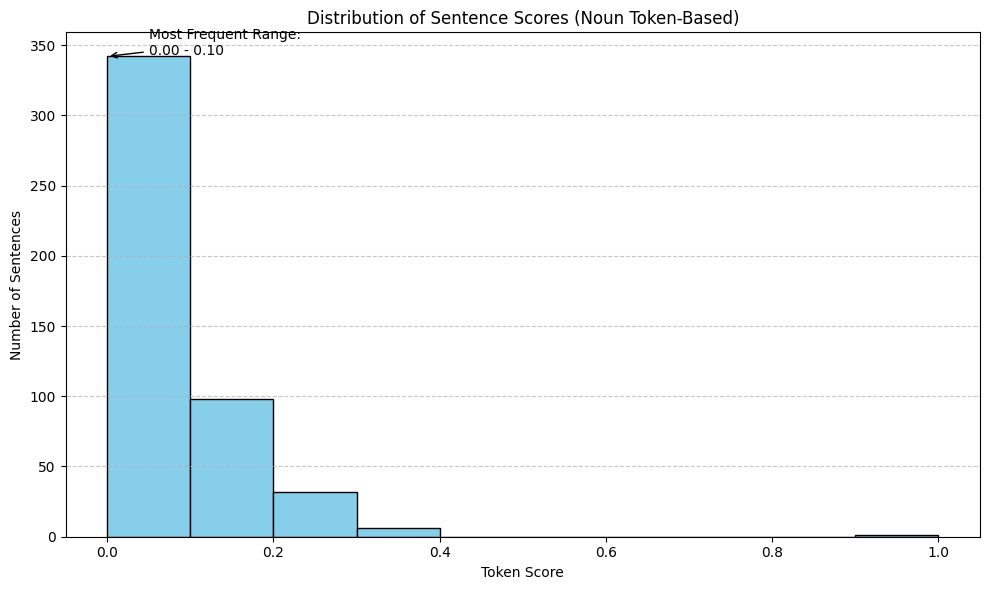

```python
# Plot token score histogram (nouns only)
plt.figure(figsize=(10, 6))
n, bins, patches = plt.hist(noun_token_scores, bins=10, edgecolor='black', color='skyblue')
plt.title("Distribution of Sentence Scores (Noun Token-Based)")
plt.xlabel("Token Score")
plt.ylabel("Number of Sentences")
plt.grid(axis='y', linestyle='--', alpha=0.7)

# Annotate most common bin
max_bin_index = n.argmax()
plt.annotate(f'Most Frequent Range:\n{bins[max_bin_index]:.2f} - {bins[max_bin_index+1]:.2f}',
             xy=(bins[max_bin_index], n[max_bin_index]),
             xytext=(bins[max_bin_index]+0.05, n[max_bin_index]+1),
             arrowprops=dict(facecolor='black', arrowstyle='->'),
             fontsize=10)

plt.tight_layout()
plt.show()
```

#### Section 8.4 Sentence Noun Lemma Scores Histogram

This histogram shows the sentence score distribution using frequent noun lemmas. Like the token-based histogram, scores are concentrated near zero, but lemmatization slightly broadens coverage by grouping related noun forms.

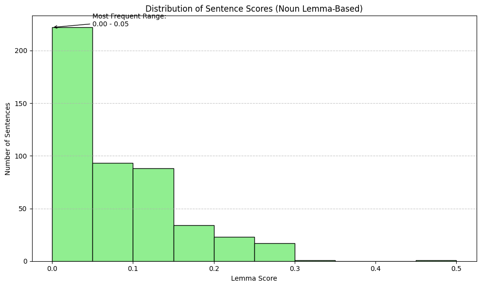

```python
# Plot lemma score histogram (nouns only)
plt.figure(figsize=(10, 6))
n, bins, patches = plt.hist(noun_lemma_scores, bins=10, edgecolor='black', color='lightgreen')
plt.title("Distribution of Sentence Scores (Noun Lemma-Based)")
plt.xlabel("Lemma Score")
plt.ylabel("Number of Sentences")
plt.grid(axis='y', linestyle='--', alpha=0.7)

# Annotate most common bin
max_bin_index = n.argmax()
plt.annotate(f'Most Frequent Range:\n{bins[max_bin_index]:.2f} - {bins[max_bin_index+1]:.2f}',
             xy=(bins[max_bin_index], n[max_bin_index]),
             xytext=(bins[max_bin_index]+0.05, n[max_bin_index]+1),
             arrowprops=dict(facecolor='black', arrowstyle='->'),
             fontsize=10)

plt.tight_layout()
plt.show()
```

#### Section 8.4.1. Noun Token vs Lemma Score Comparison Plot

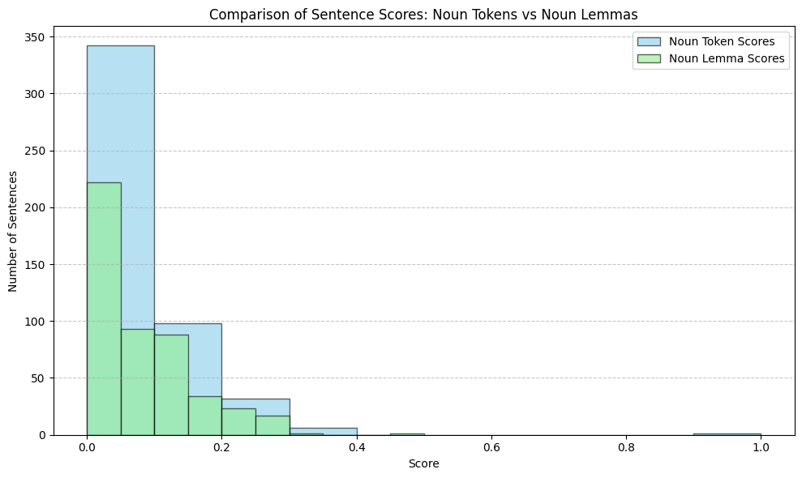

```
Noun Token Score Summary:
- Mean: 0.0659
- Median: 0.0333
- Standard Deviation: 0.0907

Noun Lemma Score Summary:
- Mean: 0.0739
- Median: 0.0556
- Standard Deviation: 0.0780
```

```python
# Plot overlapping histograms for noun-based token vs lemma scores
plt.figure(figsize=(10, 6))
plt.hist(noun_token_scores, bins=10, alpha=0.6, label='Noun Token Scores', color='skyblue', edgecolor='black')
plt.hist(noun_lemma_scores, bins=10, alpha=0.6, label='Noun Lemma Scores', color='lightgreen', edgecolor='black')
plt.title("Comparison of Sentence Scores: Noun Tokens vs Noun Lemmas")
plt.xlabel("Score")
plt.ylabel("Number of Sentences")
plt.legend()
plt.grid(axis='y', linestyle='--', alpha=0.7)
plt.tight_layout()
plt.show()

# Print statistical summary for noun token and lemma scores
def print_stats(scores, label):
    print(f"{label} Score Summary:")
    print(f"- Mean: {np.mean(scores):.4f}")
    print(f"- Median: {np.median(scores):.4f}")
    print(f"- Standard Deviation: {np.std(scores):.4f}")
    print()

print_stats(noun_token_scores, "Noun Token")
print_stats(noun_lemma_scores, "Noun Lemma")
```

#### Section 8.4.2. Interpretation of Noun Token vs Lemma Score Comparison Plot

The comparison of noun token and lemma sentence scores reveals that the majority of sentences in the article contain relatively few high-frequency noun terms, as evidenced by the clustering of scores near zero in the histogram. This pattern suggests that much of the article consists of supporting or transitional content rather than concentrated bursts of topic-heavy language. The statistical summary reinforces this observation: the mean noun token score is 0.0659 and the median is 0.0333, while the mean noun lemma score is slightly higher at 0.0739 with a median of 0.0556. These values indicate that most sentences have only a small proportion of relevant nouns, but lemmatization slightly increases the match rate by aggregating word forms—such as “headlights” and “headlight”—into a single base form. This is also reflected in the standard deviations, where the noun token scores are more variable (0.0907) than the lemma scores (0.0780), pointing to a broader spread when using raw tokens. Overall, lemmatization leads to smoother and more inclusive coverage of topic-relevant content across the article, while token-based scoring provides more granular but narrower matches.

#### Conclusion

This project demonstrated the full pipeline of web scraping, text parsing, and natural language processing (NLP) using Python to analyze a technical article on laser headlights from Hackaday. Beginning with web scraping, the HTML content was successfully extracted from the Internet Archive and stored in a .pkl file. It was then parsed using BeautifulSoup to extract clean textual data, which was normalized and saved for further linguistic analysis.

The analysis was further refined by restricting attention to nouns and proper nouns. This domain-specific filtering produced more conceptually relevant terms like “laser,” “light,” “car,” and “headlight,” while removing function words and metadata such as “says” and “2021.” The first sentence was re-evaluated using noun-based scoring, and the results were similar (Token Score: 0.1379; Lemma Score: 0.1207), though lemma-based scores across the full article still exhibited smoother distribution and higher averages (Noun Token Mean: 0.0659; Noun Lemma Mean: 0.0739).